# Gulf of Maine Seasonal Update

Adam A. Kemberling

Updated on: 2021-08-25

# Gulf of Maine Seasonal Sea Surface Temperature Report

This report was created to track the seasonal patterns in sea surface temperature regimes for the Gulf of Maine as part of efforts by [the Gulf of Maine Research Institute](https://www.gmri.org).

Satellite sea surface temperature data used was obtained from the National Center for Environmental Information (NCEI). With all maps and figures displaying [NOAA’s Optimum Interpolation Sea Surface Temperature Data](https://www.ncdc.noaa.gov/oisst).

## Gulf of Maine Extent

The spatial extent that we’ve used for any “regional” analyses or figures is displayed below. This bounding box is the same bounding box coordinates used to clip the OISST data when constructing the time series data from the array.

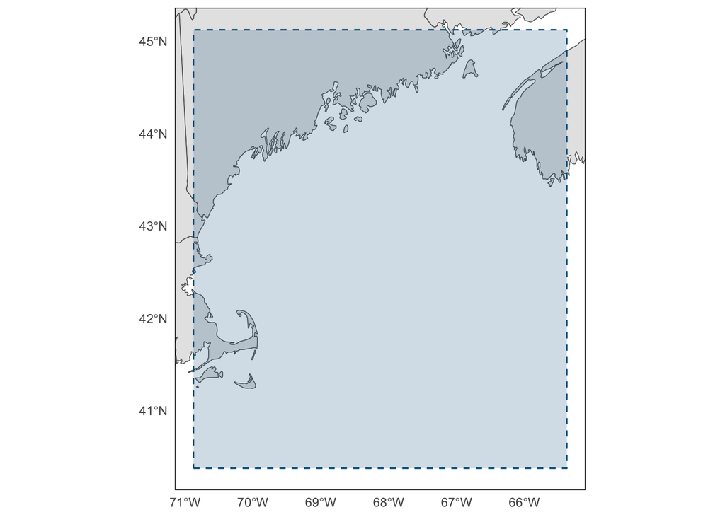

## Weekly Summer Temperature Anomalies

Area-specific time series are the most basic building block for relaying temporal trends. For the Gulf of Maine (and other areas around the world!) we can generate a time series of the mean sea surface temperature within that area for each day.

By knowing how hot or cold it was in the past we can compare how observed temperatures compare with what the expected conditions are using a climatology from a specified reference period.

This section highlights how the surface ocean temperatures of recent weeks compare to the climatological average spanning 1982-2011.

**Weekly Sea Surface Temperatures - Summer**

Temperature Unit: Celsius

| Week | Observed SST | Climate Average | Temperature Anomaly |
| --- | --- | --- | --- |
| May, 30 - Jun, 06 | 12.24 | 10.05 | 2.19 |
| Jun, 06 - Jun, 13 | 13.15 | 10.54 | 2.61 |
| Jun, 13 - Jun, 20 | 14.19 | 11.56 | 2.63 |
| Jun, 20 - Jun, 27 | 15.55 | 12.66 | 2.89 |
| Jun, 27 - Jul, 04 | 16.44 | 13.64 | 2.80 |
| Jul, 04 - Jul, 11 | 16.43 | 14.53 | 1.89 |
| Jul, 11 - Jul, 18 | 17.14 | 15.33 | 1.80 |
| Jul, 18 - Jul, 25 | 17.96 | 15.95 | 2.01 |
| Jul, 25 - Aug, 01 | 17.95 | 16.33 | 1.62 |
| Aug, 01 - Aug, 08 | 18.02 | 16.85 | 1.17 |
| Aug, 08 - Aug, 15 | 19.04 | 17.08 | 1.97 |
| Aug, 15 - Aug, 22 | 19.80 | 17.19 | 2.60 |
| Aug, 22 - Aug, 29 | 19.82 | 17.04 | 2.78 |

*Data Source: NOAA OISSTv2 Daily Sea Surface Temperature Data.*  
*Climatology Reference Period: 1982-2011.*

## Summer Temperature Record

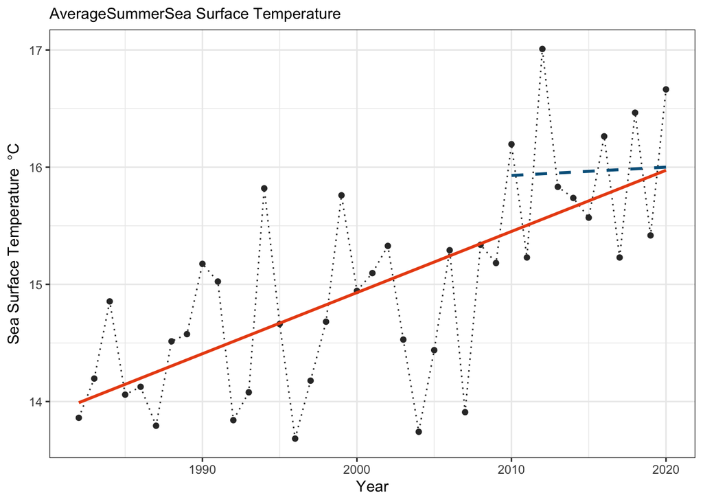

Over the period of 1982-2020 the Gulf of Maine has warmed at a rate of 0.52$\frac{^oC}{Decade}$, and more recently at a rate of 0.07$\frac{^oC}{Decade}$ for the last decade (since 2010). While the rate of summer warming has slowed, the average temperature over the three-month period has not fallen below $15^oC$ since 2007. Prior to 2007 this had only occurred seven times in 25 years (1982-2007).

## Summer Temperature Anomaly Record

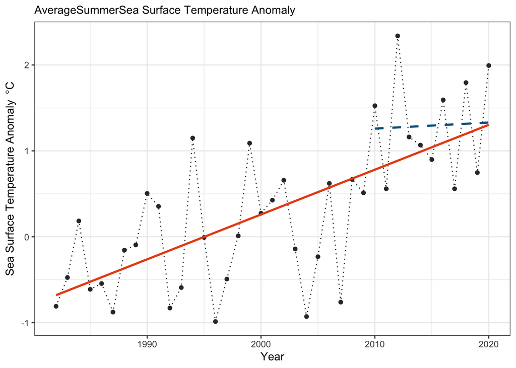

## Annual Trend

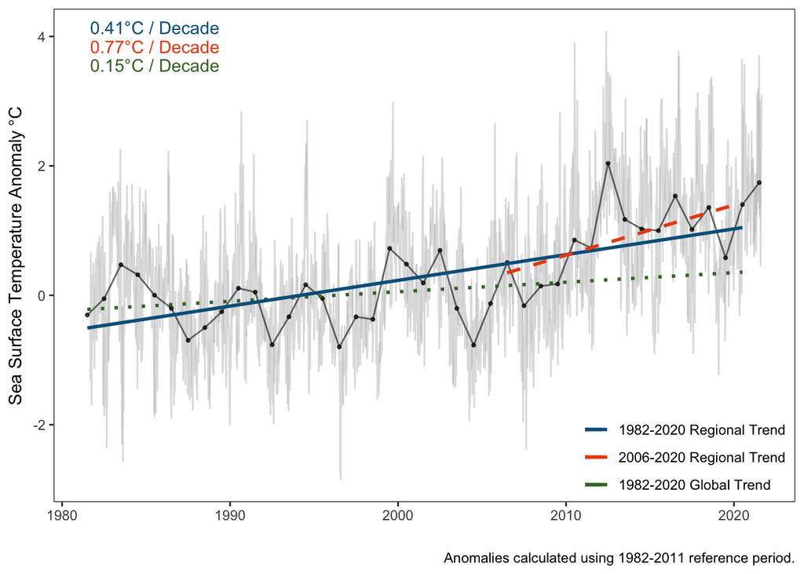

## Marine Heatwaves

A marine heatwave is defined as a situation when seawater temperatures exceeds a seasonally-varying threshold (usually the 90th percentile) for at least 5 consecutive days. Successive heatwaves with gaps of 2 days or less are considered part of the same event. The heatwave threshold used below was 90%. Note, the climate reference period is 1982-2011, so the second figure really illustrates just how anomalously warm the most recent decade has been in a climatological context.

The temperatures observed this year, and how many heatwaves have occurred can be viewed below:

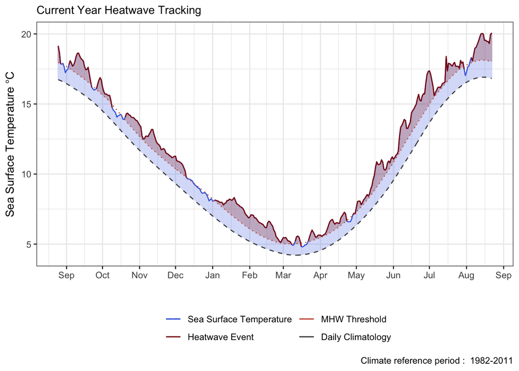

Changing the axis to anomalies rather than temperature looks like this:

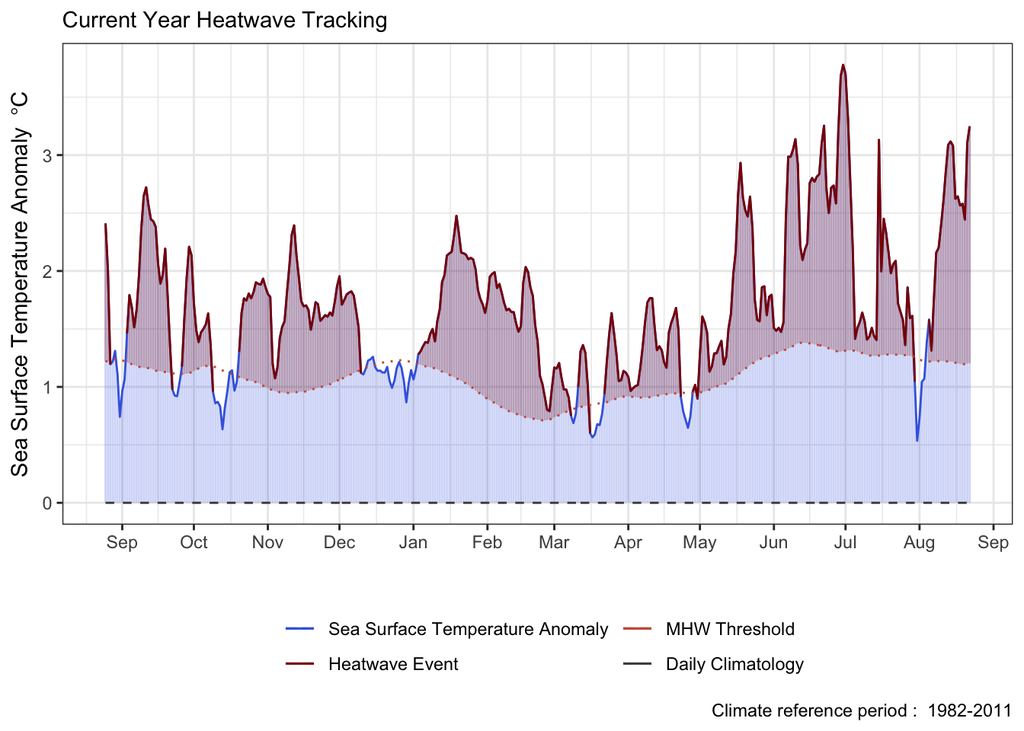

## Marine Heatwave Record

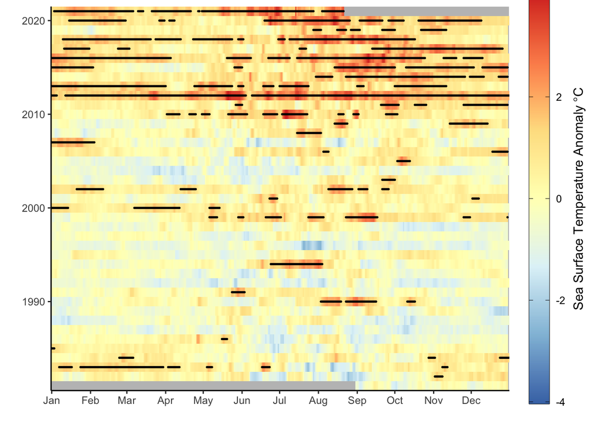

## Warming Rate Ranking

If we look at the rates of change for each grid cell, rather than the observed temperature, its possible to rank how hot each location on earth is warming relative to others.

If we take the average ranking within the Gulf of Maine we can obtain the average warming rank for the area compared to the rest of the globe.

Based on data from 1982-2020, the warming rates of Gulf of Maine have been some of the highest in the world. The area as a whole has been increasing at a rate of 0.048$^{\circ}C/year$ which is faster than 96.2% of the world’s oceans.

Over that same period locations within the Gulf of Maine have been warming at rates as low as 0.014$^{\circ}C/year$ and as rapidly as 0.097$^{\circ}C/year$, corresponding to ranks as low as 50.8% and as high as greater than or equal to 99.5%.

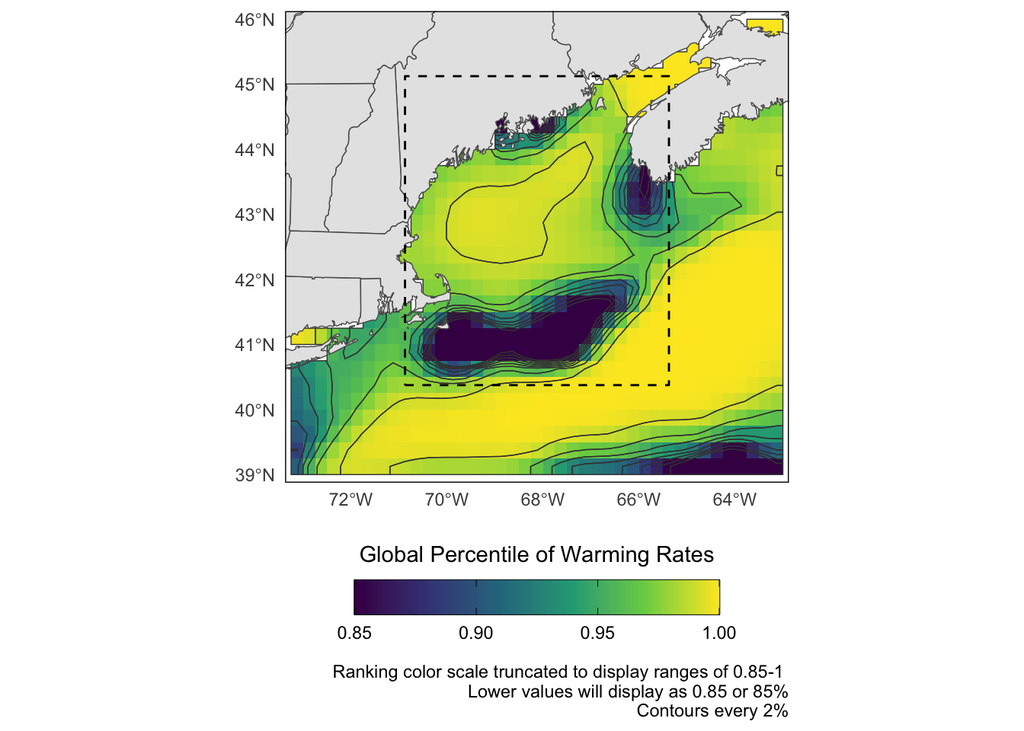